# Final Project - Google Store Games

Zihan Chen, Beibei Du, Raymart Evangelista, Shirui Huang

## PART I Introduction

### Load packages

- Load all the packages that are necessary for our project

```r
library(tidyverse)
library(dplyr)
library(broom)
library(tidymodels)
```

## PART II The Data

### Data Import

- First load the full dataset

```r
games <- read.csv("data/googleplaystore.csv")
#View(games)
```

### Data Wrangling

- When glimpsing the dataset, we found that `Type` seems serve same function as the column `Price`. It might not be necessary to remain that column. Thus we need to check what other things that `Type` has rather than Free and Paid.

```r
games |>
  distinct(Type)
```

```
##   Type
## 1 Free
## 2 Paid
## 3  NaN
## 4    0
```

```r
games |>
  filter (Type == "NaN" | Type == 0)
```

```
##                                       App Category Rating Reviews
## 1               Command & Conquer: Rivals   FAMILY    NaN       0
## 2 Life Made WI-Fi Touchscreen Photo Frame      1.9     19    3.0M
##                 Size Installs Type    Price Content.Rating            Genres
## 1 Varies with device        0  NaN        0   Everyone 10+          Strategy
## 2             1,000+     Free    0 Everyone                February 11, 2018
##    Last.Updated        Current.Ver        Android.Ver
## 1 June 28, 2018 Varies with device Varies with device
## 2        1.0.19         4.0 and up
```

- We are not sure what “NaN” and 0” are, so take a look at the whole row of the “NaN” and 0 type
  - For the “NaN” type, the price is 0 so we categorize it as “Free”
  - For the 0 type, the whole data is messed up so we decide to drop it

```r
games <-
games |>
  # we consider NaN as Free in the Type
  mutate(Type = case_when(Type == "NaN" ~ "Free", TRUE ~ Type))

games <- games |>
filter(Type != 0)
```

```r
games <-
  games |>
  filter(Rating != "NaN")
```

- This above code chunk drop all the rows that don’t have a rating

```r
games$Reviews <- as.numeric (games$Reviews)
```

- This above code chunk convert `Reviews` to numeric number

```r
games <- games |>
  separate(col = Genres, into = c("Genres", "Sub_Genres"), sep = "\\;", extra = "merge")
```

```r
games <- games |>
  # in the Price column, we get rid of the sign of dollar and take the remaining things as numeric
  mutate(across("Price", ~gsub("\\$", "", .) %>% as.numeric))
```

- Wrangle the `Price` column:
  - We need to get rid of the dollar sign in front of the Price and make everything numeric in order to do the statistical analysis later
    - Reference: https://stackoverflow.com/questions/64741916/how-to-remove-the-dollar-sign-in-r
  - However, this doesn’t finish all, since “0” does not have dollar sign in front of it and it is not being wrangled.
  - Thus we also change 0 to 0.00 as numeric value for further analysis.

```r
games$Price[games$Price == "0"] <- as.numeric(0.00)
#View(games)
```

- Lastly, since the dataset contains all apps from Google Store but we are only interested in game category, so we filter only the GAME.

```r
games <- games |>
  filter(Category == "GAME")
```

## PART III Analysis

### 3.1 Exploratory Data Analysis

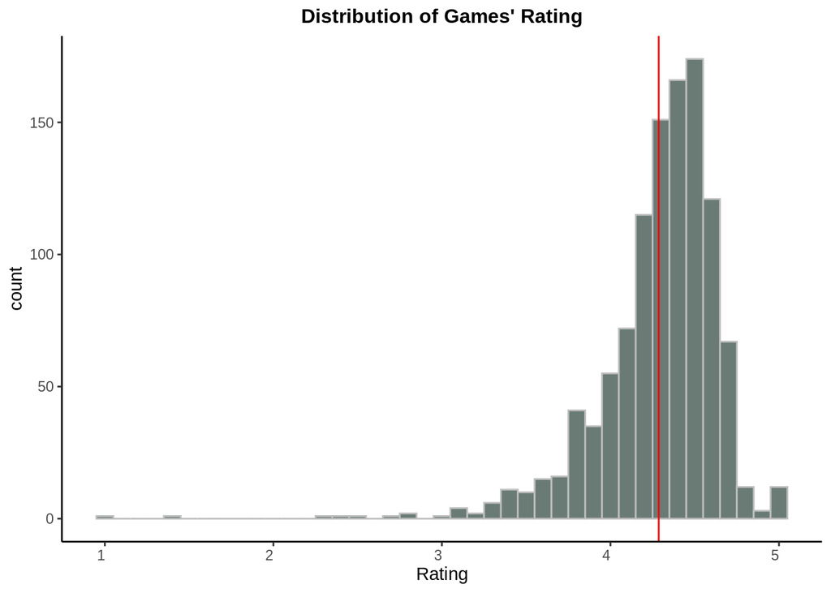

```r
#Visualization:
ggplot(data = games, mapping = aes(x = Rating)) +
  geom_histogram(color = "grey", fill = "#6a7b76", binwidth = 0.1) +
  geom_vline(xintercept = mean(games$Rating), color = "red") +
  theme_classic() +
  theme(axis.text.x = element_text(angle = 0, hjust = 1),
        plot.title = element_text(hjust = 0.5, size = 12, face = "bold")) +
  labs(title = "Distribution of Games' Rating")
```

```r
#Summarize stats:
summary(games$Rating)
```

```
##    Min. 1st Qu.  Median    Mean 3rd Qu.    Max.
##   1.000   4.100   4.400   4.286   4.500   5.000
```

```r
#Summarize stats:
Reviews_stats <- summary(games$Reviews) |> tidy()
Reviews_stats
```

```
## # A tibble: 1 × 6
##   minimum    q1 median     mean     q3  maximum
##     <dbl> <dbl>  <dbl>    <dbl>  <dbl>    <dbl>
## 1       1  4490  73539 1445232. 759838 44893888
```

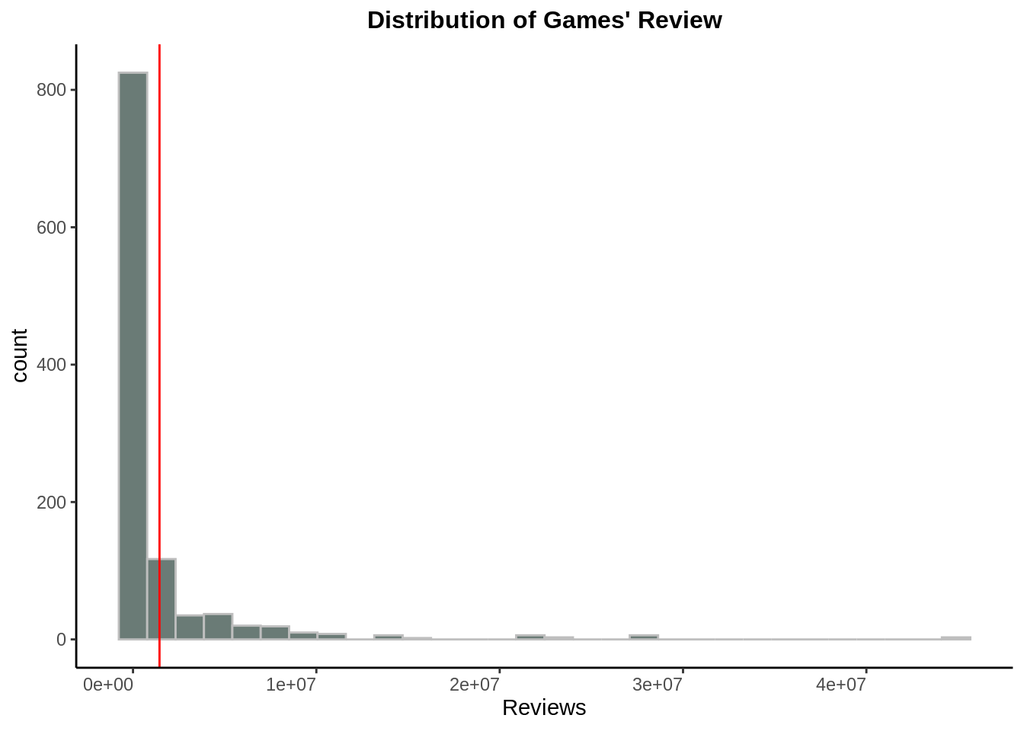

```r
#Visualization:
ggplot(data = games, mapping = aes(x = Reviews)) +
  geom_histogram(color = "grey", fill = "#6a7b76") +
  geom_vline(xintercept = mean(Reviews_stats$mean[1]), color = "red") +
  theme_classic() +
  theme(axis.text.x = element_text(angle = 0, hjust = 1),
        plot.title = element_text(hjust = 0.5, size = 12, face = "bold")) +
  labs(title = "Distribution of Games' Review")
```

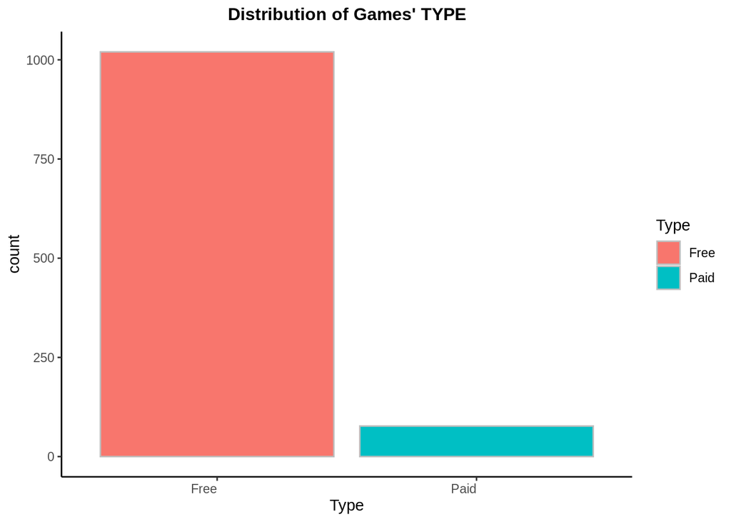

```r
ggplot(data = games, aes(x = Type, fill = Type)) +
  geom_bar(color = "grey", ) +
  theme_classic() +
  theme(axis.text.x = element_text(angle = 0, hjust = 1),
        plot.title = element_text(hjust = 0.5, size = 12, face = "bold")) +
  labs(title = "Distribution of Games' TYPE")
```

- Look at the types of those games - There are way more free games than paid games.

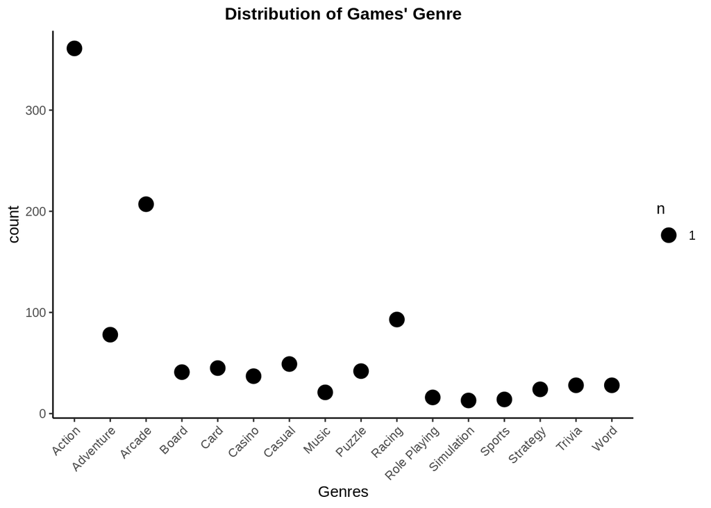

```r
games_genres <-
  games |>
  group_by(Genres) |>
  summarise(mean = mean(Rating),
            count = n())

ggplot(data = games_genres, aes(x = Genres, y = count)) +
  geom_count() +
  theme_classic() +
  theme(axis.text.x = element_text(angle = 45, hjust = 1),
        plot.title = element_text(hjust = 0.5, size = 12, face = "bold")) +
  labs(title = "Distribution of Games' Genre")
```

- Looking at the distribution of the games’ genre, we can see that Action game is the most popular genre, followed by arcade and racing game, other games have relatively low popularity.

### 3.2 Data Analysis

#### *Hypothesis 1*: game’s popularity might affect its rating, while more popular game (`Reviews`) tends to get higher rating score.

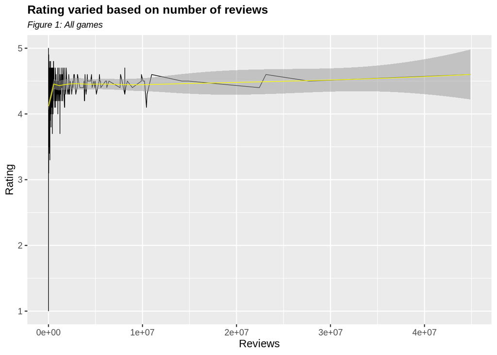

```r
reivew_line <- ggplot(data = games, aes(x = Reviews, y = Rating)) +
  geom_line(size = 0.3) +
  geom_smooth(method = "loess", span = 0.3, se = TRUE, size = 0.3, alpha = 0.5, color = "yellow") +
  labs(title = "Rating varied based on number of reviews",
       subtitle = "Figure 1: All games") +
  guides(fill = "none") +
  theme_gray() +
  theme(
    plot.title = element_text(size = 12, face = "bold"),
    plot.subtitle = element_text(size = 9, face = "italic"))



review3_line <- games |>
  filter(Rating > 3.5) |>
  ggplot(aes(x = Reviews, y = Rating)) +
  geom_line() +
  geom_smooth(method = "loess", span = 0.3, se = TRUE, size = 0.3, alpha = 0.5, color = "yellow") +
  labs(title = "Rating varied based on number of reviews",
       subtitle = "Figure 2: Games that have rating higer than 3.5") +
  theme_grey() +
  theme(
    plot.title = element_text(size = 12, face = "bold"),
    plot.subtitle = element_text(size = 9, face = "italic"))

review_zoomed_line <- games |>
  filter(Rating > 3.5,
         Reviews < 20000000) |>
  ggplot(aes(x = Reviews, y = Rating)) +
  geom_line() +
  geom_smooth(method = "loess", span = 0.1, se = TRUE, size = 0.3, alpha = 0.5, color = "yellow") +
  labs(title = "Rating varied based on number of reviews",
       subtitle = "Figure 3: Games that have rating higer than 3.5 and less than 30M reviews") +
  theme_grey() +
  theme(
    plot.title = element_text(size = 12, face = "bold"),
    plot.subtitle = element_text(size = 9, face = "italic"))

reivew_line
```

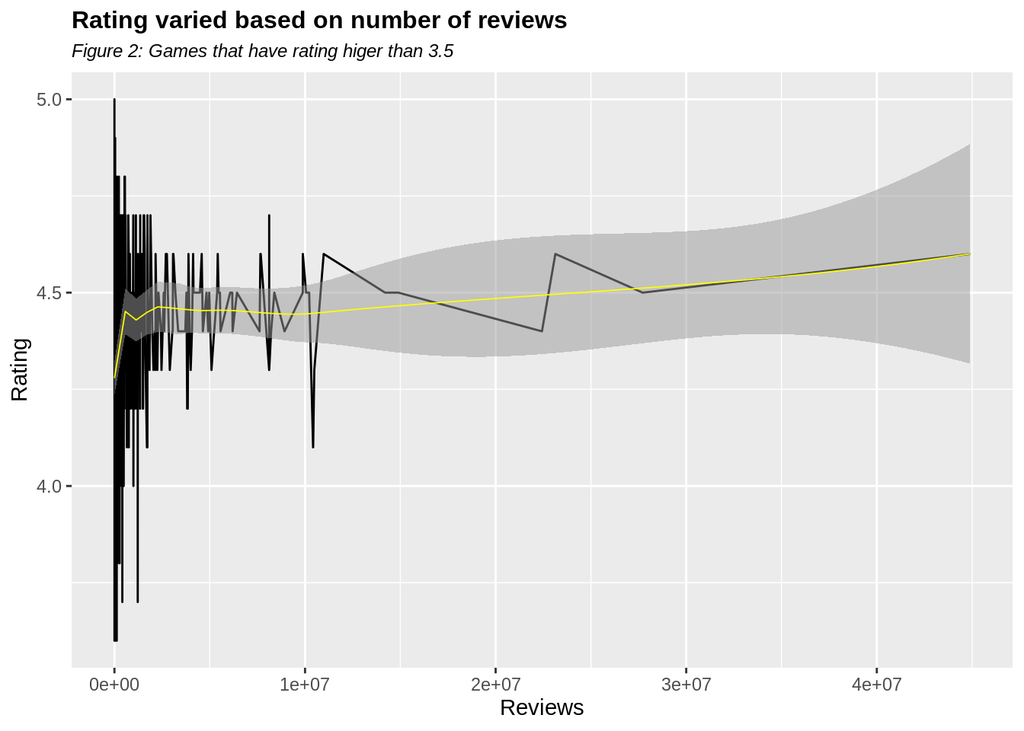

```r
review3_line
```

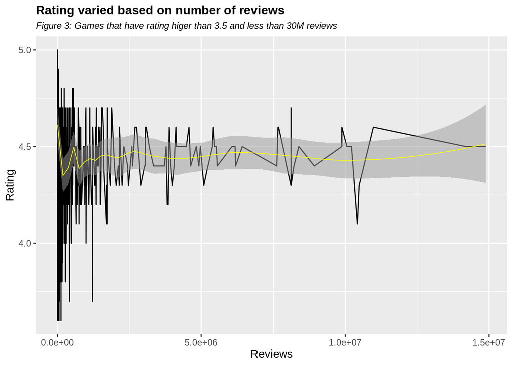

```r
review_zoomed_line
```

```r
#gridExtra::grid.arrange(reivew_line, review3_line, ncol=2)
```

**Visualization Explanation 1:**

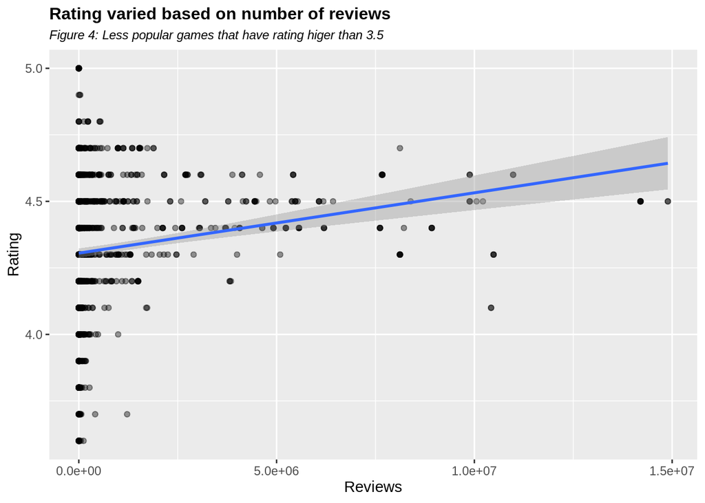

```r
games <- games |>
  mutate(
    Popularity = case_when(
      # We consider Reviews < 20000000(0) as less popular and >= as more popular (1)
      Reviews < 20000000 ~ 0,
      Reviews >= 20000000 ~ 1,
      TRUE ~ Reviews
    )
  )
# We let the new created Popularity column to be in the character form
games$Popularity <- as.character(games$Popularity)

games <- games |>
  mutate(
    Popularity = case_when(
      # as aforementioned, 0 as less popular and 1 as more popular
      Popularity == "0" ~ "less popular",
      Popularity == "1" ~ "more popular",
      TRUE ~ Popularity
    )
  )

#Less popular games:
games |>
  # we set 3.5 as a benchmark
  filter(Rating > 3.5,
         Reviews < 20000000) |>
  ggplot(aes(y = Rating, x = Reviews)) +
  geom_point(alpha = 0.4) +
  geom_smooth(method = "lm", se = T) +
  labs(title = "Rating varied based on number of reviews",
       subtitle = "Figure 4: Less popular games that have rating higer than 3.5") +
  theme_grey() +
  theme(
    plot.title = element_text(size = 12, face = "bold"),
    plot.subtitle = element_text(size = 9, face = "italic"))
```

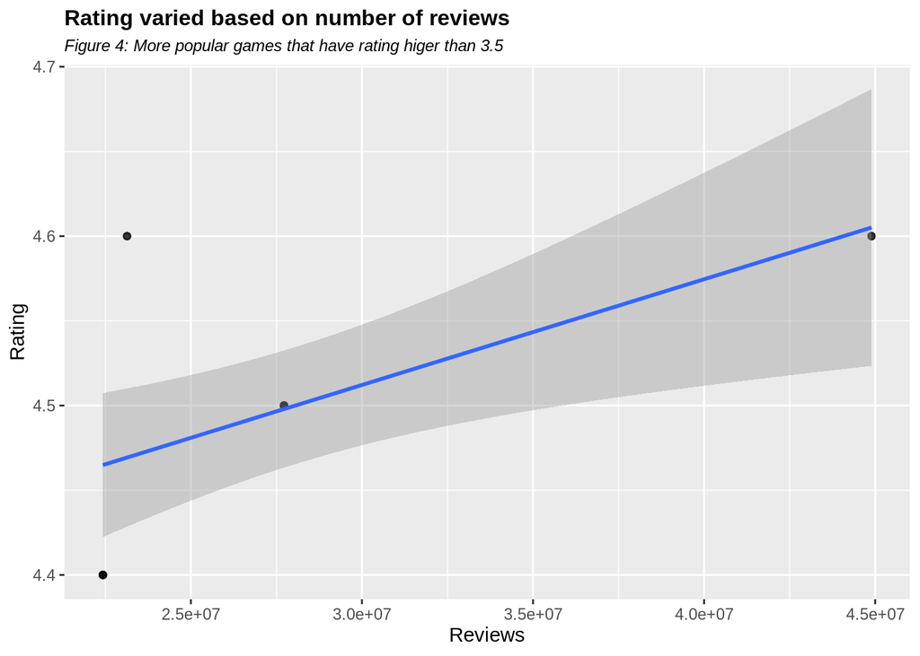

```r
#More popular games:
games |>
  filter(Rating > 3.5,
         Reviews > 20000000) |>
  ggplot(aes(y = Rating, x = Reviews)) +
  geom_point(alpha = 0.4) +
  geom_smooth(method = "lm", se = T) +
  labs(title = "Rating varied based on number of reviews",
       subtitle = "Figure 4: More popular games that have rating higer than 3.5") +
  theme_grey() +
  theme(
    plot.title = element_text(size = 12, face = "bold"),
    plot.subtitle = element_text(size = 9, face = "italic"))
```

**Visualization Explanation 2:**

```r
review_model <- lm(Rating ~ Reviews, data = games)
popularity_model <- lm(Rating ~ Popularity, data = games)

review_model |> tidy()
```

```
## # A tibble: 2 × 5
##   term            estimate     std.error statistic      p.value
##   <chr>              <dbl>         <dbl>     <dbl>        <dbl>
## 1 (Intercept) 4.27         0.0115           371.   0
## 2 Reviews     0.0000000146 0.00000000257      5.67 0.0000000178
```

```r
popularity_model |> tidy()
```

```
## # A tibble: 2 × 5
##   term                   estimate std.error statistic p.value
##   <chr>                     <dbl>     <dbl>     <dbl>   <dbl>
## 1 (Intercept)               4.28     0.0111    386.    0
## 2 Popularitymore popular    0.217    0.0866      2.51  0.0123
```

```r
glance(review_model)$adj.r.squared
```

```
## [1] 0.02768232
```

```r
glance(popularity_model)$adj.r.squared
```

```
## [1] 0.004802433
```

**Model Explanation:**

- So we assess the linear models by two means:
  - numeric ~ numeric model (Use `Reviews` as predictor)
    - significant
    - adj.r.sqr = 0.02768232 (Use `Reviews` as predictor could explain 2.7% of variability of the `Rating`)
  - numeric ~ categorical model (Use `Popularity` as predictor, a game is either less popular or more popular based on how many reviews it got)
    - significant
    - adj.r.sqr = 0.004802433
- By looking at the adjusted r-squared, both models only count for a small portion of variations in Rating. Although the model that uses `Reviews` as the predictor is slightly better, we do not suggest either of them could sufficiently predict a game’s rating.

#### *Hypothesis 2*: game’s rating might be most affected by the genre, certain genre might always be rated better than others.

- The following code is used to visualize the games categorized by Genres.

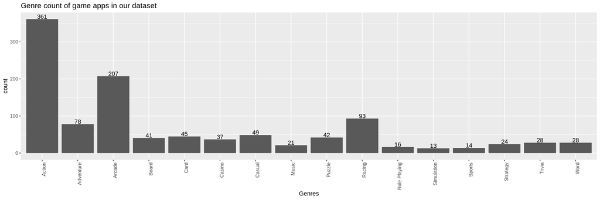

```r
games |>
  ggplot(aes(x = Genres)) +
  geom_bar() +
  labs(title = "Genre count of game apps in our dataset") +
  theme(axis.text.x = element_text(angle = 90, hjust = 1)) + # easier to read genre names
  geom_text(stat='count', aes(label=..count..), vjust=-.1) # add count value on top of each bar
```

**Visualization Explanation 1:**

- By looking at the plot above, there are a lot less games in our dataset that are under most genres. Most of the games in our dataset fall into the genres of Action and Arcade.
- We have less data points in the other genres aside from Action, Arcade, and Rating
- The following code is used to look at the mean and median rating of each genre and visualize the distribution of rating for each genre

```r
games |>
  group_by(Genres) |> # use group_by so that data points are grouped by Genre name
  summarize(mean = mean(Rating), median = median(Rating)) # summarize the mean and median Rating for each Genre
```

```
## # A tibble: 16 × 3
##    Genres        mean median
##    <chr>        <dbl>  <dbl>
##  1 Action        4.29   4.3
##  2 Adventure     4.20   4.3
##  3 Arcade        4.30   4.4
##  4 Board         4.29   4.4
##  5 Card          4.09   4.2
##  6 Casino        4.29   4.4
##  7 Casual        4.44   4.4
##  8 Music         4.21   4.3
##  9 Puzzle        4.53   4.6
## 10 Racing        4.17   4.2
## 11 Role Playing  4.4    4.35
## 12 Simulation    4.39   4.5
## 13 Sports        4.54   4.5
## 14 Strategy      4.40   4.4
## 15 Trivia        4.04   4.25
## 16 Word          4.41   4.4
```

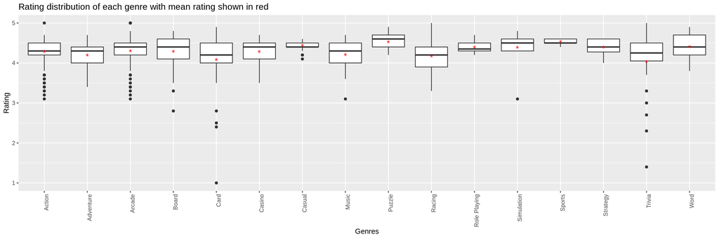

```r
# visualize the distribution of Rating for each Genre
games |>
  ggplot(aes(x = Genres, y = Rating)) +
  geom_boxplot() +
  labs(title = "Rating distribution of each genre with mean rating shown in red") +
  theme(axis.text.x = element_text(angle = 90, hjust = 1)) + # easier to view Genre names
  stat_summary(fun= mean, geom="point", shape=42, size=4, color = "red") # visualize the mean Rating for each Genre
```

**Visualization Explanation 2:**

- From the visualization we note that:
  - Most genres have a mean rating less than the median rating. Since median > mean for many genres, the ratings are skewed left. Low rating scores are pulling the mean lower than the median.
  - In the genres Casual, Role Playing, Sports, and Word, the median < mean. So for these, the ratings are skewed right such that high rating scores are pulling the mean higher than the median.
- In this next code chunk, we are creating a linear model to predict Rating from Genres and see how the adjustedd R squared performs

```r
# create linear regression model that predicts Rating from Genres
m_rating_game_category <- linear_reg() |>
  set_engine("lm") |>
  fit(Rating ~ Genres, data = games)

# tidy output
m_rating_game_category |>
  tidy()
```

```
## # A tibble: 16 × 5
##    term                estimate std.error statistic   p.value
##    <chr>                  <dbl>     <dbl>     <dbl>     <dbl>
##  1 (Intercept)         4.29        0.0186 230.      0
##  2 GenresAdventure    -0.0849      0.0442  -1.92    0.0550
##  3 GenresArcade        0.0182      0.0308   0.590   0.555
##  4 GenresBoard         0.00653     0.0583   0.112   0.911
##  5 GenresCard         -0.199       0.0559  -3.57    0.000377
##  6 GenresCasino        0.000337    0.0611   0.00552 0.996
##  7 GenresCasual        0.159       0.0539   2.95    0.00327
##  8 GenresMusic        -0.0719      0.0794  -0.905   0.366
##  9 GenresPuzzle        0.240       0.0577   4.16    0.0000341
## 10 GenresRacing       -0.113       0.0411  -2.75    0.00610
## 11 GenresRole Playing  0.114       0.0904   1.26    0.208
## 12 GenresSimulation    0.106       0.0999   1.06    0.288
## 13 GenresSports        0.250       0.0964   2.59    0.00973
## 14 GenresStrategy      0.110       0.0746   1.47    0.142
## 15 GenresTrivia       -0.247       0.0694  -3.56    0.000391
## 16 GenresWord          0.125       0.0694   1.79    0.0729
```

```r
# look at adjusted R squared
glance(m_rating_game_category)$adj.r.squared
```

```
## [1] 0.06255319
```

**Model Explanation:**

- By looking at the p-values, many of the game genres have p-values > 0.05. Game genres that have p-values < 0.05 include:
  - genres that fall under Card, Casual, Puzzle, Racing, Sports, and Trivia
    - these genres are significantly different than the Action genre
- There are many different genres so we will interpret a few:
  - The intercept is 4.29 which is the predicted Rating for a game that fall under the genre Action.
  - A genre in the Adventure category is subject to a DECREASE of 0.085 in its predicted rating.
  - A genre in the Card category is subject to a DECREASE of 0.2 in its predicted rating.
  - A genre in the Sports category is subject to an INCREASE of 0.25 in its predicted rating.
  - A genre in the Trivia category is subject to a DECREASE of 0.25 in its predicted rating.
- Looking at the adjusted R-squared value, 6.3% the variation can be explained by this model

#### *Hypothesis 3*: people love free games! Free games might have higher ratings than paid games, and we can further explore how the variation of the price affects the rating. (Bella)

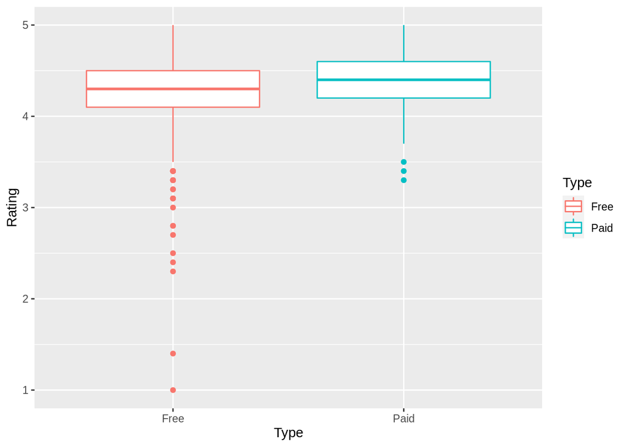

```r
# a box plot to see the Q1,median, and Q3 comparison
ggplot(data = games, mapping = aes(x = Type, y = Rating,color = Type)) + geom_boxplot()
```

**Visualization Explanation:** - According to the boxplot above, we could see that Q1, median and Q3 is higher in the Paid apps. Thus it is surprisingly opposite of our original hypothesis.Since there are way more free games than the paid games, there are more lowers ratings in the free apps.Thus it is reasonable to have lower rating apps for the Free apps. The median for the Paid is higher, resulting our hypothesis might not hold. We then further do the statistical model to see if that’s statistically valid.

- Then we checked the count for Free games vs. Paid games

```r
# if the count is evenly distributed
games |>
  count(Type)
```

```
##   Type    n
## 1 Free 1020
## 2 Paid   77
```

- The above code confirm that there are way more Free apps compared with the Paid apps. And that might lead to the more lower ratings in the Free games.

```r
# linear model 1: Type vs. Rating
TypeRating_Model <- linear_reg() |>
  set_engine("lm") |>
  fit(Rating ~ Type, data = games)
tidy(TypeRating_Model)
```

```
## # A tibble: 2 × 5
##   term        estimate std.error statistic p.value
##   <chr>          <dbl>     <dbl>     <dbl>   <dbl>
## 1 (Intercept)   4.28      0.0114    375.    0
## 2 TypePaid      0.0929    0.0431      2.16  0.0313
```

**Model Explanation** - The linear model here is y-hat = 4.27980392 + 0.09292335 * X(1 if it is paid, 0 if it is free)

- X is the `Type` (explanatory variable), and the Y-hat is the response variable, indicating the predicted ratings of the apps.
- From this linear model, we could see that if the app is a paid app, then the rating will increase by 0.09292335.
- Also the p-value is less than 0.05, which is the most used p critical value used in social science and academic field to define the significant difference in the analysis.
- The slope means that for every 1-unit increase in Type (0 means free and 1 means paid), the ratings are predicted to have an increase in their score (relative to the intercept) of approximately 0.09292335.

```r
# R squared
glance(TypeRating_Model)$r.squared
```

```
## [1] 0.004225182
```

```r
glance(TypeRating_Model)$adj.r.squared
```

```
## [1] 0.003315799
```

- The above is the $r^2$ an adjusted $r^2$ for the linear model, and it is 0.004225182 and 0.003315799 respectively.
- The adjusted r square is less than the r square.
- A multi-variant linear model is conducted below to see how the price will affect the rating of the games

```r
# linear model 2: Type + Price vs. Rating
TypeRatingPrice_Model <- linear_reg() |>
  set_engine("lm") |>
  fit(Rating ~ Type + Price, data = games)
tidy(TypeRatingPrice_Model)
```

```
## # A tibble: 3 × 5
##   term        estimate std.error statistic p.value
##   <chr>          <dbl>     <dbl>     <dbl>   <dbl>
## 1 (Intercept)  4.28       0.0114   375.      0
## 2 TypePaid     0.0798     0.0634     1.26    0.209
## 3 Price        0.00361    0.0128     0.282   0.778
```

**Explanation** - The linear model here is y-hat = 4.27980392 + 0.07979365 * X1(1 if it is paid, 0 if it is free) + 0.00360603*X2(Price)

- X is the `Type` and `Price`(explanatory variables), and the Y-hat is the response variable, indicating the predicted ratings of the apps.
- From this linear model, we could see that if the app is a paid app, then the rating will increase by 0.07979365 and for every one dollar increase in the `Price`, the rating will increase by 0.00360603.
- Also the p-value is larger than 0.05, then it is not statistically significant.
- By looking at the p-values, Both of the explanatory variables have p-values > 0.05.
- 0.429% the variation can be explained by this model

```r
glance(TypeRatingPrice_Model)$r.squared
```

```
## [1] 0.004297768
```

```r
glance(TypeRatingPrice_Model)$adj.r.squared
```

```
## [1] 0.002477472
```

- Since Type + Price is not statistically significant, how about Price alone as the explnatory variable?

```r
TypePrice_Model <- linear_reg() |>
  set_engine("lm") |>
  fit(Rating ~ Price, data = games)
tidy(TypePrice_Model)
```

```
## # A tibble: 2 × 5
##   term        estimate std.error statistic p.value
##   <chr>          <dbl>     <dbl>     <dbl>   <dbl>
## 1 (Intercept)   4.28     0.0112     381.    0
## 2 Price         0.0154   0.00869      1.77  0.0768
```

- The linear model is y-hat(Rating) = 4.2823944 + 0.0153852*X(Price)
- The model shows as the price goes up for 1 dollar then the Rating will go up 0.0153852.
- The p value for Price is 0.07680473, which is larger than 0.05. Thus this is not statistical significant as well.

```r
glance(TypePrice_Model)$r.squared
```

```
## [1] 0.002856808
```

```r
glance(TypePrice_Model)$adj.r.squared
```

```
## [1] 0.001946175
```

- Looking at the adjusted R-squared value, 0.1946175% the variation can be explained by this model. And this is a very small number.

## PART IV Conclusion

> *By comparing several models (`REVEIW`, `GENRE`, `TYPE`, `TYPE+PRICE`, `PRICE`), we found that*:
- The number of review is generally not a helpful explanatory variable to predict a game’s rating.
- Genre as a predictor is helpful in predicting the Rating of a game.
- Type as a predictor alone is helpful in predicting the Rating of a game, however, Type + Price and Price alone aren’t good predictors in predicting the Rating of a game.

> *Limitation*:
- Although the games dataset records the games information from the Google store, there is not enough data to extend the result to a broader case. Since the games are from the Google store, we can’t conclude all game ratings are predicted by the `Review` number, `Type`(Free of Paid) and `Genre` . There are many other game platforms, such as Steam and Epic, which focus more on games alone. Moreover, we have dropped the NaN values that might affect the results of our study. But we can’t replace the NaN values with the average values or any other possible responses. Thus we drop NaN values and consider only the valid entries.

> *Future Direction*:
- the original data set also contains version information, such as when is the last update and what is the current version. In real life, an app usually gets different rating when there is a update. Therefore, we would suggest to use version information to further investigate how version updates will affect a game’s rating. Will frequent update result a better rating, or people just don’t like too many updates.